# Spotify Data : Exploratory Analysis with R

# Preliminaries

First, I downloaded and installed the packages required to perform some simple analysis and data visualisation.

```r
library(supernova)
library(readr)
library(tidyverse)
library(ggplot2)
library(lm.beta)
library(ggpubr)
library(mosaic)
library(Hmisc)
library(dplyr)
library(kableExtra)
```

# THE DATA

## About the Data

Spotify is a Swedish audio streaming and media services provider, founded in April 2006 by Daniel Ek and Martin Lerentzon. With an estimated 551 million million active users and 220 million paying subscribers (as of Q1 of 2023), Spotify is one the largest music streaming service providers.

Spotify offers its users digital copyright restricted recorded visual and audio content, from music and music videos, to podcasts and audio books. As a freemium service, basic features are free with advertisements, with premium features, such as offline and advertisement free listening, being offered via paid subscription.

While Spotify has experienced year-on-year increases in total revenue, with a total revenue of 11.72bn USD in 2022, it has never published a net profit. Of greater concern, Spotify experienced an overall loss of 331 million USD in Q1 of 2023, leading to share prices to fall by 14%. In an attempt to mitigate their financial struggles, the price of a premium subscriptions were increased across the US, UK and Australia in July 2023: even with record levels of active users, they are still pushed to increase prices at a time of high inflation and economic uncertainty.

Spotify owes its popularity to its ability to provide users with their preferred music, when they want it, how they want it, and in playlists that are designed for their preferences. By examining the qualities of the music that has historically been most popular, Spotify can make informed decisions regarding which new and upcoming artists to support, and know more about its audiences preferences.

In this R project, I will examine the top10s dataset, developed by data scientist Leonardo Henrique which consists of 603 songs that were in the top songs of the year worldwide from 2010 to 2019 (as measured by Billboard). It contains the following variables:

*…1*: ID *title*: Song title *artist*: name of the musician, band or artist *top genre* : Most salient genre of the song *year*: year the song was on the Billboard *bpm* : beats per minute (tempo of the song) *nrgy*: The energy of the song (higher values - faster, more energetic) *dnce*: The ‘danceability’ of the song (higher values indicate it is more suitable for dancing based on its tempo, rhythm stability, beat strength) *dB* : Decibel - loudness of the song *live*: Likelihood that the song was recorded with a live audience *val*: Valence (higher values indicate the song is more ‘positive’, happy or cheerful) *dur*: The duration of the song in seconds *acous*: Likelihood that the song is acoustic *spch*: Speechiness (higher values indicate more spoken words) *pop*: Popularity (higher values indicate higher popularity)

## Loading the Data

First, I have loaded the data into the R environment, and reviewing the head, or the first six rows, of the dataset.

```r
library(readr)
spotify_data <- read_csv("top10s.csv")
```

```
## ──────────────────────────────────────────────────────── Delimiter: "," chr
## (3): title, artist, top genre dbl (12): ...1, year, bpm, nrgy, dnce, dB, live,
## val, dur, acous, spch, pop
```

```r
View(spotify_data)
```

# DATA INSPECTION AND CLEANING

First, I inspected the data be calling the column names, the first 6 rows of the data frame and a list of columns and data types.

```r
colnames(spotify_data)
```

```
##  [1] "...1"      "title"     "artist"    "top genre" "year"      "bpm"
##  [7] "nrgy"      "dnce"      "dB"        "live"      "val"       "dur"
## [13] "acous"     "spch"      "pop"
```

```r
head(spotify_data)
```

| ...1 | title | artist | top genre | year | bpm | nrgy | dnce | dB | live | val | dur | acous | spch | pop |
| --- | --- | --- | --- | --- | --- | --- | --- | --- | --- | --- | --- | --- | --- | --- |
| 1 | Hey, Soul Sister | Train | neo mellow | 2010 | 97 | 89 | 67 | -4 | 8 | 80 | 217 | 19 | 4 | 83 |
| 2 | Love The Way You Lie | Eminem | detroit hip hop | 2010 | 87 | 93 | 75 | -5 | 52 | 64 | 263 | 24 | 23 | 82 |
| 3 | TiK ToK | Kesha | dance pop | 2010 | 120 | 84 | 76 | -3 | 29 | 71 | 200 | 10 | 14 | 80 |
| 4 | Bad Romance | Lady Gaga | dance pop | 2010 | 119 | 92 | 70 | -4 | 8 | 71 | 295 | 0 | 4 | 79 |
| 5 | Just the Way You Are | Bruno Mars | pop | 2010 | 109 | 84 | 64 | -5 | 9 | 43 | 221 | 2 | 4 | 78 |
| 6 | Baby | Justin Bieber | canadian pop | 2010 | 65 | 86 | 73 | -5 | 11 | 54 | 214 | 4 | 14 | 77 |

```r
str(spotify_data)
```

```
## spc_tbl_ [603 × 15] (S3: spec_tbl_df/tbl_df/tbl/data.frame)
##  $ ...1     : num [1:603] 1 2 3 4 5 6 7 8 9 10 ...
##  $ title    : chr [1:603] "Hey, Soul Sister" "Love The Way You Lie" "TiK ToK" "Bad Romance" ...
##  $ artist   : chr [1:603] "Train" "Eminem" "Kesha" "Lady Gaga" ...
##  $ top genre: chr [1:603] "neo mellow" "detroit hip hop" "dance pop" "dance pop" ...
##  $ year     : num [1:603] 2010 2010 2010 2010 2010 2010 2010 2010 2010 2010 ...
##  $ bpm      : num [1:603] 97 87 120 119 109 65 120 148 93 126 ...
##  $ nrgy     : num [1:603] 89 93 84 92 84 86 78 76 37 72 ...
##  $ dnce     : num [1:603] 67 75 76 70 64 73 75 52 48 79 ...
##  $ dB       : num [1:603] -4 -5 -3 -4 -5 -5 -4 -6 -8 -4 ...
##  $ live     : num [1:603] 8 52 29 8 9 11 4 12 12 7 ...
##  $ val      : num [1:603] 80 64 71 71 43 54 82 38 14 61 ...
##  $ dur      : num [1:603] 217 263 200 295 221 214 203 225 216 235 ...
##  $ acous    : num [1:603] 19 24 10 0 2 4 0 7 74 13 ...
##  $ spch     : num [1:603] 4 23 14 4 4 14 9 4 3 4 ...
##  $ pop      : num [1:603] 83 82 80 79 78 77 77 77 76 73 ...
##  - attr(*, "spec")=
##   .. cols(
##   ..   ...1 = col_double(),
##   ..   title = col_character(),
##   ..   artist = col_character(),
##   ..   `top genre` = col_character(),
##   ..   year = col_double(),
##   ..   bpm = col_double(),
##   ..   nrgy = col_double(),
##   ..   dnce = col_double(),
##   ..   dB = col_double(),
##   ..   live = col_double(),
##   ..   val = col_double(),
##   ..   dur = col_double(),
##   ..   acous = col_double(),
##   ..   spch = col_double(),
##   ..   pop = col_double()
##   .. )
##  - attr(*, "problems")=<externalptr>
```

As columns 6-15 have numeric data that indicates a variable related to the track characteristics, I am also going to call a statistical summary of the numeric data

```r
summary(spotify_data[c(6:15)])
```

```
##       bpm             nrgy           dnce             dB
##  Min.   :  0.0   Min.   : 0.0   Min.   : 0.00   Min.   :-60.000
##  1st Qu.:100.0   1st Qu.:61.0   1st Qu.:57.00   1st Qu.: -6.000
##  Median :120.0   Median :74.0   Median :66.00   Median : -5.000
##  Mean   :118.5   Mean   :70.5   Mean   :64.38   Mean   : -5.579
##  3rd Qu.:129.0   3rd Qu.:82.0   3rd Qu.:73.00   3rd Qu.: -4.000
##  Max.   :206.0   Max.   :98.0   Max.   :97.00   Max.   : -2.000
##       live            val             dur            acous
##  Min.   : 0.00   Min.   : 0.00   Min.   :134.0   Min.   : 0.00
##  1st Qu.: 9.00   1st Qu.:35.00   1st Qu.:202.0   1st Qu.: 2.00
##  Median :12.00   Median :52.00   Median :221.0   Median : 6.00
##  Mean   :17.77   Mean   :52.23   Mean   :224.7   Mean   :14.33
##  3rd Qu.:24.00   3rd Qu.:69.00   3rd Qu.:239.5   3rd Qu.:17.00
##  Max.   :74.00   Max.   :98.00   Max.   :424.0   Max.   :99.00
##       spch             pop
##  Min.   : 0.000   Min.   : 0.00
##  1st Qu.: 4.000   1st Qu.:60.00
##  Median : 5.000   Median :69.00
##  Mean   : 8.358   Mean   :66.52
##  3rd Qu.: 9.000   3rd Qu.:76.00
##  Max.   :48.000   Max.   :99.00
```

Now that I have looked at the data, serveral issues have been identified : 1. Column 1 does not have a name 2. Some songs seem to have the value ‘0’, which may indicate a data entry error 3. There may be repeated songs in the dataset, which should be deleted.

## Renaming the First Column

The first column will be renamed ‘ID_No’, and I will check that this has been achieved by calling the column names again

```r
names(spotify_data)[1]<- "ID_No"
names(spotify_data)[4]<- "genre"
colnames(spotify_data)
```

```
##  [1] "ID_No"  "title"  "artist" "genre"  "year"   "bpm"    "nrgy"   "dnce"
##  [9] "dB"     "live"   "val"    "dur"    "acous"  "spch"   "pop"
```

## Deleting Repeated Songs

First, I have listed the distinct values in the columns, and checking for any repeated values

```r
unique(spotify_data$title)
```

```
##   [1] "Hey, Soul Sister"
##   [2] "Love The Way You Lie"
##   [3] "TiK ToK"
##   [4] "Bad Romance"
##   [5] "Just the Way You Are"
##   [6] "Baby"
##   [7] "Dynamite"
##   [8] "Secrets"
##   [9] "Empire State of Mind (Part II) Broken Down"
##  [10] "Only Girl (In The World)"
##  [11] "Club Can't Handle Me (feat. David Guetta)"
##  [12] "Marry You"
##  [13] "Cooler Than Me - Single Mix"
##  [14] "Telephone"
##  [15] "Like A G6"
```

[output cut: 569 more lines]

```r
unique(spotify_data$year)
```

```
##  [1] 2010 2011 2012 2013 2014 2015 2016 2017 2018 2019
```

While it appears that the dataset does range from 2010-2019 as stated, the presence of 584 unique song names in a data set of 603 songs is cause for concern.

I am going to call the duplicated values to examine them

```r
spotify_data$title[duplicated(spotify_data$title)]
```

```
##  [1] "Just the Way You Are"
##  [2] "Marry You"
##  [3] "Written in the Stars (feat. Eric Turner)"
##  [4] "Castle Walls (feat. Christina Aguilera)"
##  [5] "We Are Never Ever Getting Back Together"
##  [6] "A Little Party Never Killed Nobody (All We Got)"
##  [7] "Hello"
##  [8] "Sugar"
##  [9] "The Hills"
## [10] "Love Yourself"
## [11] "Stitches"
## [12] "Company"
## [13] "Runnin' (Lose It All)"
## [14] "Here"
## [15] "All I Ask"
## [16] "I Like It"
## [17] "Say Something"
## [18] "First Time"
## [19] "Kissing Strangers"
```

Upon further research, the majority of these songs have the same issue : they were published and entered the charts toward the end of one year, but persisted in the charts until the next year, meaning that they were entered into the data set twice. To resolve this, and remove the duplicate entries, I will place all songs within the year they were published. - “Hello”,” I Like It” and “Say Something” are only considered a “duplicate entry” in that two very popular songs on two separate years had the same title, so I will not remove these from the data set. - Sugar is duplicated and has been entered twice with different popularity scores. Upon further research, the song has a popularity score of 81, so the entry with the erroneous score will be deleted

```r
spotify_data <-
  spotify_data%>%
  filter(title != 'Just the Way You Are' | year != 2011) %>%
filter(title != 'Marry You' | year != 2011) %>%
filter(title != 'Written in the Stars (feat. Eric Turner)' | year != 2011) %>%
filter(title != 'Castle Walls (feat. Christina Aguilera)' | year != 2011) %>%
filter(title != 'We Are Never Ever Getting Back Together' | year != 2013) %>%
filter(title != 'A Little Party Never Killed Nobody (All We Got)' | year != 2014) %>%
filter(title != 'Sugar' | pop != 66) %>%
filter(title != 'The Hills' | year != 2016) %>%
filter(title != 'Love Yourself' | year != 2016) %>%
filter(title != 'Company' | year != 2016)  %>%
filter(title != "Runnin' (Lose It All)" | year != 2016) %>%
filter(title != 'Here' | year != 2016) %>%
filter(title != 'All I Ask' | year != 2017) %>%
filter(title != 'First Time' | year != 2018) %>%
filter(title != 'Kissing Strangers' | year != 2019)
```

## Checking songs with values of ‘0’

Having a song with a value of 0 is not, in it self, cause for concern because it is possible for a song to have very low energy, acousticity, popularity or danceability. However, if a song has multiple 0 values, this may indicate a data entry error, and thus that song should be deleted.

```r
spotify_data %>%
  select_all() %>%
  filter(bpm == 0 |
         nrgy == 0 |
         dnce == 0 |
         dB == 0 |
         live == 0 |
         dur == 0 |
         spch == 0 |
         pop  == 0 )
```

| ID_No | title | artist | genre | year | bpm | nrgy | dnce | dB | live | val | dur | acous | spch | pop |
| --- | --- | --- | --- | --- | --- | --- | --- | --- | --- | --- | --- | --- | --- | --- |
| 51 | Hello | Martin Solveig | big room | 2010 | 128 | 98 | 67 | -3 | 10 | 45 | 191 | 1 | 3 | 0 |
| 139 | Blow Me (One Last Kiss) | P!nk | dance pop | 2012 | 114 | 92 | 60 | -3 | 25 | 75 | 256 | 0 | 4 | 0 |
| 268 | Not a Bad Thing | Justin Timberlake | dance pop | 2014 | 86 | 73 | 59 | -6 | 38 | 46 | 266 | 27 | 6 | 0 |
| 363 | L.A.LOVE (la la) | Fergie | dance pop | 2015 | 202 | 39 | 48 | -8 | 26 | 27 | 193 | 2 | 9 | 0 |
| 443 | Million Years Ago | Adele | british soul | 2016 | 0 | 0 | 0 | -60 | 0 | 0 | 227 | 0 | 0 | 0 |

Song number 443 appears to have an unusually large number of values of 0. As this is a large dataset, this song will be removed

```r
spotify_data <- spotify_data %>%
  filter(ID_No != 443)
```

## Data Set Description After Cleaning

After cleaning, this data set contains 588 that were in the top songs of the year from 2010 to 2019 (as measured by Billboard. 15 songs were removed due to data entry errors or duplicate entries.

# ANALYSIS GOALS

The business objective of this analysis would be to *identify key factors that influence a track’s popularity, finding potential trends in popular music that will provide a guideline for Spotify’s decisions to support new and upcoming artists* Questions: 1.Which were the most popular songs? 2.Which were the most popular genres? 3.Which were the most popular artists from 2010-2019? 4.Have the characteristics of top songs (danceability,energy,valence,live) changed over time? 5.What is the relationship between energy and valence?

Using these insights, I also am going to train and build a classifier to predict a song’s genre based on its characteristics : this could assist Spotify’s data analysts in categorisation and clustering of song types.

## Songs

Now, I want to answer the first question : Which is the most popular songs?

```r
most_popular <-
  spotify_data%>%
  arrange(desc(pop))%>%
  group_by(artist)
most_popular
```

| ID_No | title | artist | genre | year | bpm | nrgy | dnce | dB | live | val | dur | acous | spch | pop |
| --- | --- | --- | --- | --- | --- | --- | --- | --- | --- | --- | --- | --- | --- | --- |
| 573 | Memories | Maroon 5 | pop | 2019 | 91 | 32 | 76 | -7 | 8 | 57 | 189 | 84 | 5 | 99 |
| 574 | Lose You To Love Me | Selena Gomez | dance pop | 2019 | 102 | 34 | 51 | -9 | 21 | 9 | 206 | 58 | 4 | 97 |
| 575 | Someone You Loved | Lewis Capaldi | pop | 2019 | 110 | 41 | 50 | -6 | 11 | 45 | 182 | 75 | 3 | 96 |
| 576 | Señorita | Shawn Mendes | canadian pop | 2019 | 117 | 54 | 76 | -6 | 9 | 75 | 191 | 4 | 3 | 95 |
| 577 | How Do You Sleep? | Sam Smith | pop | 2019 | 111 | 68 | 48 | -5 | 8 | 35 | 202 | 15 | 9 | 93 |
| 578 | South of the Border (feat. Camila Cabello & Cardi B) | Ed Sheeran | pop | 2019 | 98 | 62 | 86 | -6 | 9 | 67 | 204 | 15 | 8 | 92 |
| 579 | Trampoline (with ZAYN) | SHAED | electropop | 2019 | 127 | 46 | 62 | -6 | 14 | 50 | 184 | 56 | 3 | 92 |
| 580 | Happier | Marshmello | brostep | 2019 | 100 | 79 | 69 | -3 | 17 | 67 | 214 | 19 | 5 | 90 |
| 581 | Truth Hurts | Lizzo | escape room | 2019 | 158 | 62 | 72 | -3 | 12 | 41 | 173 | 11 | 11 | 90 |
| 582 | Good as Hell (feat. Ariana Grande) - Remix | Lizzo | escape room | 2019 | 96 | 89 | 67 | -3 | 74 | 48 | 159 | 30 | 6 | 90 |

[output cut: 578 more lines]

The most popular song in the dataset, as of 2019, was Memories by Maroon 5. To ensure the popularity index is not skewed by duration since the song’s publication (for example, older songs may be less popular in 2019 than in the year of their initial release), I am going to plot the most popular song of the year, for every year.

```r
most_popular_song <- spotify_data %>%
  group_by(year) %>%
  filter(pop == max(pop)) %>%
  arrange(desc(year))

most_popular_song_tab <- most_popular_song %>%
  select(title,
         artist,
         year, dur,
         pop)
most_popular_song_tab %>%
  kbl(caption = "Most Popular Songs of The Year 2010-2019") %>%
  kable_classic(html_font = "Alrai")
```

Most Popular Songs of The Year 2010-2019

| title | artist | year | dur | pop |
| --- | --- | --- | --- | --- |
| Memories | Maroon 5 | 2019 | 189 | 99 |
| One Kiss (with Dua Lipa) | Calvin Harris | 2018 | 215 | 86 |
| Shape of You | Ed Sheeran | 2017 | 234 | 87 |
| Cake By The Ocean | DNCE | 2016 | 219 | 81 |
| Don’t Let Me Down | The Chainsmokers | 2016 | 208 | 81 |
| In the Name of Love | Martin Garrix | 2016 | 196 | 81 |
| Thinking out Loud | Ed Sheeran | 2015 | 282 | 84 |
| I’m Not The Only One | Sam Smith | 2015 | 239 | 84 |
| The Hills | The Weeknd | 2015 | 242 | 84 |
| All of Me | John Legend | 2014 | 270 | 86 |
| Underneath the Tree | Kelly Clarkson | 2013 | 230 | 88 |
| Titanium (feat. Sia) | David Guetta | 2012 | 245 | 80 |
| A Thousand Years | Christina Perri | 2011 | 285 | 81 |
| Hey, Soul Sister | Train | 2010 | 217 | 83 |

### Summary

From merely observing this table, there are serveral details to note about the most popular songs of the year throughout the decade: - Five of the songs are in the ‘dance pop’ genre, and four of the songs are in the ‘pop’ genre, indicating ‘pop’, as a genre, to be a high predictor of popularity and song success. - In both 2015 and 2016 there were ties between three songs for the title of most popular song. This may indicate that a particular phenomenon was occuring in the music industry at the time, or it may be a coincidence.

## Artists

Song popularity is an important variable to observe, but more important, from the perspective of business managers deciding whether to sign a record deal, is the popularity and success of artists. By knowing the characteristics that predict artist success, both Spotify and the artists they support can make more informed decisions.

I have visualised the artists that are most present frequently in the dataset, to find out which artists produced the largest amount of top songs from 2010 to 2019.

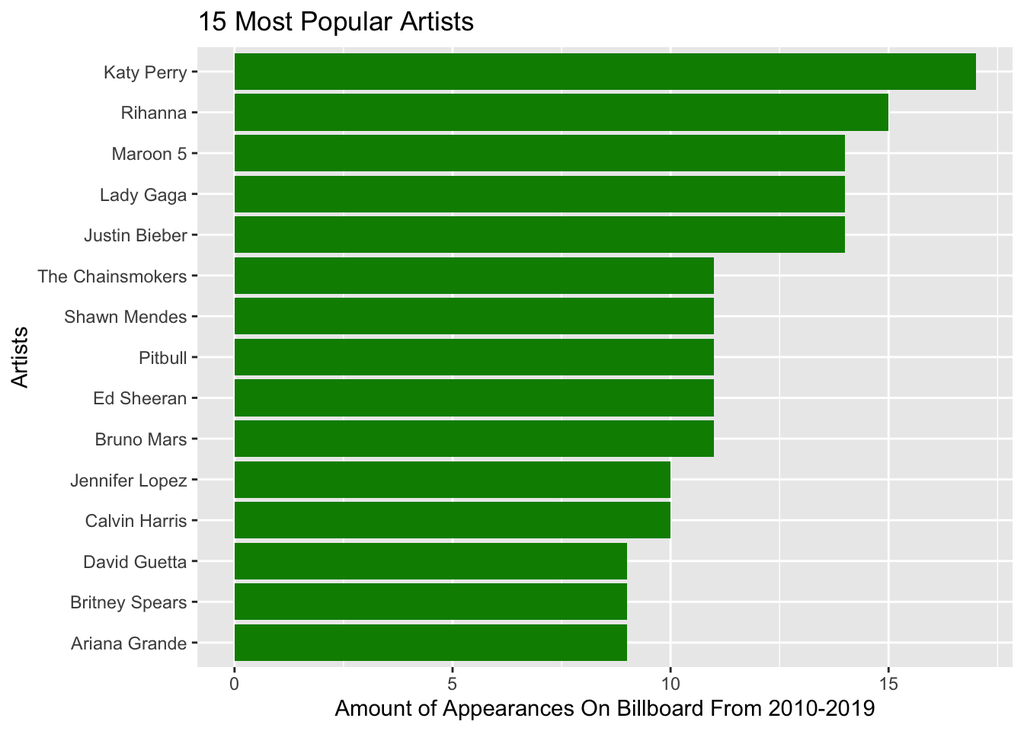

```r
most_popular_artist <-
  most_popular%>%
  count(artist)%>%
  arrange(desc(n))

most_popular_artist%>%
  head(15)%>%
  ggplot(aes(x=reorder(artist,n),y=n))+
  geom_col(fill="green4")+ggtitle("15 Most Popular Artists")+
  ylab("Amount of Appearances On Billboard From 2010-2019")+
  xlab("Artists")+
  coord_flip()
```

### Summary

This bar chart provides a wealth of valuable information : - 6 of the top artists are women, 7 are men, and 2 are bands. In light of this information, gender may be discarded as a predictor of success, but executives may be more inclined to support independent artists, as opposed to bands or groups.

## Genre

First, I want to see all the types of genres in the dataset, and their frequencies

```r
 genre_table <- table(spotify_data$genre)
View(genre_table)
```

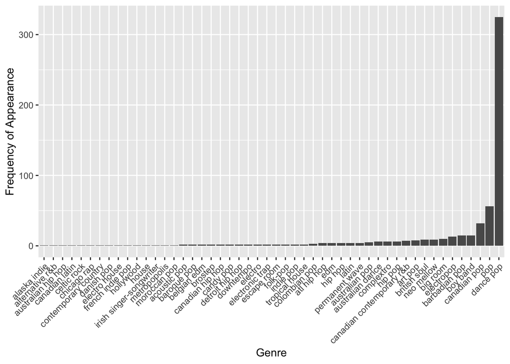

```r
# re-order levels
compute <- function(x) {
  genre_table <- table(x)
  factor(x, levels = names(sort(genre_table)))
}

# plotting the data
ggplot(data=spotify_data, aes(x = compute(genre))) +
  geom_bar() +
  ylab('Frequency of Appearance')+
  xlab("Genre")+
   theme(axis.text.x=element_text(angle=45,hjust=1))
```

### Summary

From merely observing this table and bar chart, there are serveral details to note about the most frequently occuring genres throughout the decade: - Dance Pop occurs 325 times in the dataset, meaning that over half of the songs that were in the top 10 billboard throughout the 2010s belonged to the dance pop genre

## Trends Over Time

###Danceability As Dance Pop was the most frequently occuring genre in the billboard, I wanted to find out if there has been any change in the mean danceability scores of popular songs over time.

```r
# Finding the average danceability score of songs for each year
mean_dnce<-
  spotify_data %>%
  group_by(year) %>%
  summarise_at(vars(dnce), list(dnce = mean))
mean_dnce
```

| year | dnce |
| --- | --- |
| 2010 | 64.52941 |
| 2011 | 64.04082 |
| 2012 | 65.71429 |
| 2013 | 62.02857 |
| 2014 | 62.29825 |
| 2015 | 63.54255 |
| 2016 | 65.10811 |
| 2017 | 65.46875 |
| 2018 | 67.26984 |
| 2019 | 69.70968 |

Now, any changes in the mean danceability score can be visualised here

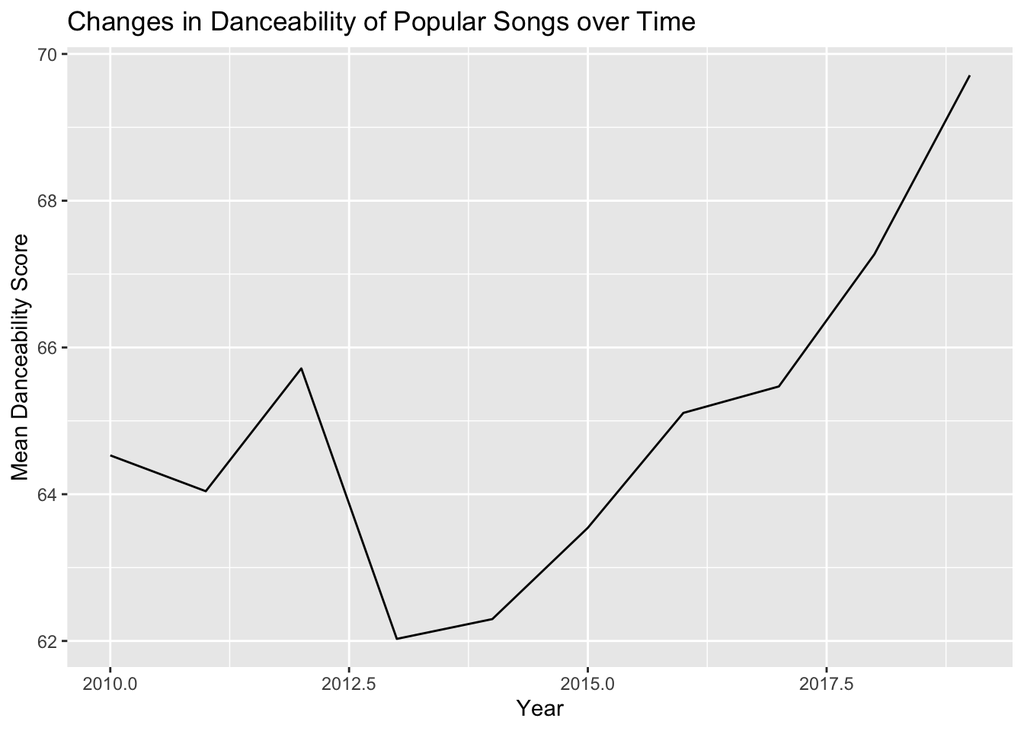

```r
ggplot(mean_dnce, aes(x = year, y = dnce)) +
  geom_line() +
  labs(title = "Changes in Danceability of Popular Songs over Time",
       x = "Year",
       y = "Mean Danceability Score")
```

### Energy

Energy may be a significant component of the danceability score, and/or of the pop genre, so I also examined the trends in average song energy over time

```r
mean_nrgy<-
  spotify_data %>%
  group_by(year) %>%
  summarise_at(vars(nrgy), list(nrgy = mean))
mean_nrgy
```

| year | nrgy |
| --- | --- |
| 2010 | 77.90196 |
| 2011 | 73.89796 |
| 2012 | 75.48571 |
| 2013 | 73.95714 |
| 2014 | 67.87719 |
| 2015 | 70.24468 |
| 2016 | 68.08108 |
| 2017 | 69.81250 |
| 2018 | 65.57143 |
| 2019 | 64.74194 |

Now, any changes in the mean energy score can be visualised here

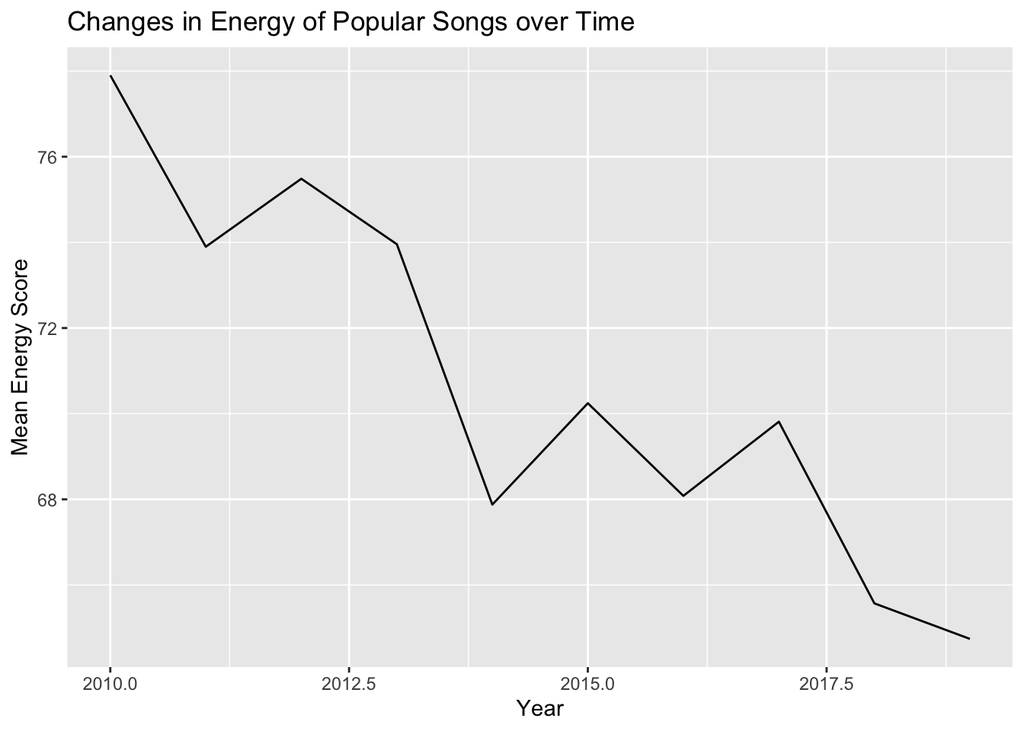

```r
ggplot(mean_nrgy, aes(x = year, y = nrgy)) +
  geom_line() +
  labs(title = "Changes in Energy of Popular Songs over Time",
       x = "Year",
       y = "Mean Energy Score")
```

```r
mean_val<-
  spotify_data %>%
  group_by(year) %>%
  summarise_at(vars(val), list(valence = mean))
mean_val
```

| year | valence |
| --- | --- |
| 2010 | 57.00000 |
| 2011 | 53.87755 |
| 2012 | 64.17143 |
| 2013 | 52.87143 |
| 2014 | 52.08772 |
| 2015 | 52.14894 |
| 2016 | 46.78378 |
| 2017 | 52.56250 |
| 2018 | 48.46032 |
| 2019 | 50.80645 |

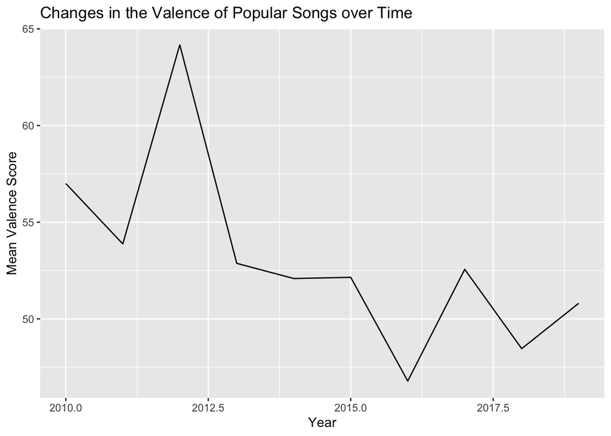

```r
ggplot(mean_val, aes(x = year, y = valence)) +
  geom_line() +
  labs(title = "Changes in the Valence of Popular Songs over Time",
       x = "Year",
       y = "Mean Valence Score")
```

###Live Since 2012, over 50% of the Western population has owned a smartphone. This change has driven large changes in how people communicate, interact and socialise. Although the COVID-19 pandemic certainly decreased the likelihood that music was recorded live, I wanted to see whether the average likelihood of a song being recorded live had been decreasing *prior* to lockdowns.

```r
mean_live<-
  spotify_data %>%
  group_by(year) %>%
  summarise_at(vars(live), list(live = mean))
mean_live
```

| year | live |
| --- | --- |
| 2010 | 21.17647 |
| 2011 | 21.36735 |
| 2012 | 15.82857 |
| 2013 | 19.82857 |
| 2014 | 17.43860 |
| 2015 | 18.40426 |
| 2016 | 17.74324 |
| 2017 | 15.37500 |
| 2018 | 14.82540 |
| 2019 | 15.16129 |

Now, any changes in the mean live score can be visualised here

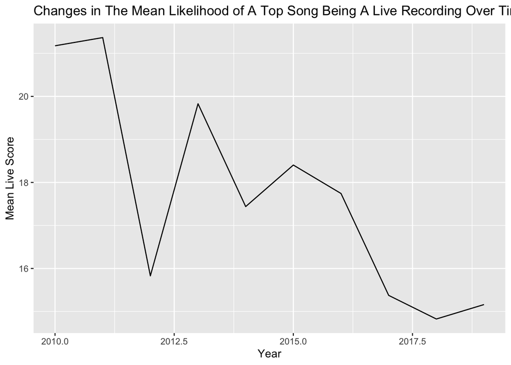

```r
ggplot(mean_live, aes(x = year, y = live)) +
  geom_line() +
  labs(title = "Changes in The Mean Likelihood of A Top Song Being A Live Recording Over Time",
       x = "Year",
       y = "Mean Live Score")
```

### Summary

As seen in these visualisations, the mean valence, likelihood of a song being recorded live, and energy of songs has been decreasing over time, indicating a shift in audience tastes throughout the decade. However, these findings sharply contrast with a general increase in the average song’s danceability over time : while audiences of the 2020s may be more likely to listen to low valence, low energy songs that arent’ recorded live, they are also more likely to listen to songs that have a high danceability factor. ## LINEAR REGRESSION : ENERGY & VALENCE

Both the mean valence and mean energy of popular songs appear to have decreased over time in a similar fashion. This could suggest that there is a relationship between trends in valence and trends in energy : if energy and valence are related, data-driven trend forecasters could predict changes in the characteristics of popular songs by only following one metric.

To test for this relationship, I have elected to perform a linear regression. This method only makes two assumptions : that of linearity, and that of no anomalies.

First, I am testing for the presence of a linear relationship, with this specific question : ” Is there a linear relationship between the’Valence’ and ‘Energy’ in the Spotify Top 10s 2010-2019 dataset?” Based on the visualisations above, my hypothesis is that the relationship between the two variables should be greater than zero

### Descriptives

First, I am examining the means and standard deviations of the two variables.

```r
favstats(~val, data=spotify_data)
```

|  | min | Q1 | median | Q3 | max | mean | sd | n | missing |
| --- | --- | --- | --- | --- | --- | --- | --- | --- | --- |
|  | 4 | 35 | 52 | 70 | 98 | 52.41327 | 22.45406 | 588 | 0 |

```r
favstats(~nrgy, data=spotify_data)
```

|  | min | Q1 | median | Q3 | max | mean | sd | n | missing |
| --- | --- | --- | --- | --- | --- | --- | --- | --- | --- |
|  | 4 | 61 | 74 | 82 | 98 | 70.62755 | 15.99656 | 588 | 0 |

Neither column appears to contain irrelevant data or missing values.

Inspecting the descriptives shows that the Valence variable has a mean of 52.4, and a standard deviation of 22.5. Most mean valence scores appear to fall above the scale median, but there is a large degree of variation around this average. The Energy variable, on the other hand, has a mean of 70.6, and a standard deviation of 16.0. It is difficult to interpret the meaning of this mean score, but it appears that the majority of the variables cluster above the mean. It is certain that there is greater variance across valence scores compared to energy scors.

### Correlation between Valence and Energy

An initial step in any test of relationships is to inspect the extent to which our variables co-vary.

```r
val_nrgy_cov <- spotify_data %>%
  select(val,nrgy)

cov(val_nrgy_cov, method="pearson")
```

```
##           val     nrgy
## val  504.1850 147.1218
## nrgy 147.1218 255.8900
```

The covariance of valence and energy is 147.12. This is a positive value and indicates a positive relationship between song valence and energy. However, this number does not indicate the size of the covariance, as the level of the covariance depends on the scale of measurement for these variables.

As such, a standardised metric of covariance is required : Pearson’s R - a standardised metric that runs between -1 and +1. The closer Pearson’s r is to +/-1, the larger the relationship.

```r
cor(val_nrgy_cov)
```

```
##            val      nrgy
## val  1.0000000 0.4095958
## nrgy 0.4095958 1.0000000
```

Pearson’s r is 0.41. According to Cohen (1988, 1992), the effect size is low if the value of r varies around 0.1, medium if r varies around 0.3, and large if r varies more than 0.5. An r of .41 is a medium correlation.

The rcorr function can indicate the significance of this Pearson’s R

```r
library(Hmisc)
rcorr(as.matrix(val_nrgy_cov))
```

```
##       val nrgy
## val  1.00 0.41
## nrgy 0.41 1.00
##
## n= 588
##
##
## P
##      val nrgy
## val       0
## nrgy  0
```

We can see that Pearson’s r is the same as we have calculated but the difference here is that underneath the correlation matrix we have a matrix for P. The p value associated with our correlation coeffcient is 0, therefore we can reject the null hypothesis. A zero relationship seems unlikely in the population. The positive correlation between valence and energy is, therefore, statistically significant.

I have visualised this relationship via a scatterplot

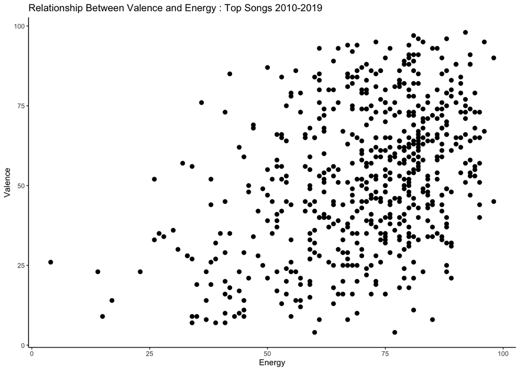

```r
spotify_data %>%
ggplot(aes(x = nrgy, y = val)) +
    geom_point() +
  theme_classic(base_size = 8)+
  labs(title = "Relationship Between Valence and Energy : Top Songs 2010-2019",
       x = "Energy",
       y = "Valence")
```

I have also elected to draw the best-fitting regression line :

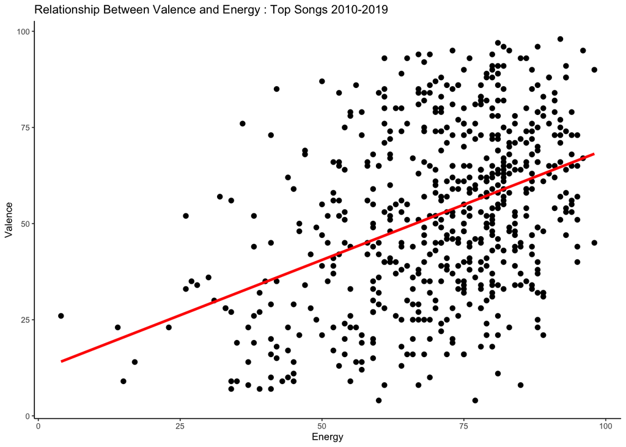

```r
spotify_data %>%
ggplot(aes(x = nrgy, y = val)) +
    geom_point() +
    stat_smooth(method = "lm",
        col = "red",
        se = FALSE,
        linewidth = 1) +
  theme_classic(base_size = 8)+
    labs(title = "Relationship Between Valence and Energy : Top Songs 2010-2019",
       x = "Energy",
       y = "Valence")
```

### Setting up the linear regression model of Valence

Given evidence for a linear relationship between valence and energy, I built a linear model of valence to examine the extent to which a song’s energy predicted its valence.

```r
valence.model <- lm(val ~ 1 + nrgy, data = spotify_data)
summary(valence.model)
```

```
##
## Call:
## lm(formula = val ~ 1 + nrgy, data = spotify_data)
##
## Residuals:
##     Min      1Q  Median      3Q     Max
## -52.677 -15.445  -0.328  14.511  49.046
##
## Coefficients:
##             Estimate Std. Error t value Pr(>|t|)
## (Intercept)  11.8065     3.8306   3.082  0.00215 **
## nrgy          0.5749     0.0529  10.869  < 2e-16 ***
## ---
## Signif. codes:  0 '***' 0.001 '**' 0.01 '*' 0.05 '.' 0.1 ' ' 1
##
## Residual standard error: 20.5 on 586 degrees of freedom
## Multiple R-squared:  0.1678, Adjusted R-squared:  0.1663
## F-statistic: 118.1 on 1 and 586 DF,  p-value: < 2.2e-16
```

The intercept, or b0 is 11.8, which represents the predicted valence when nrgy = 0. The nrgy estimate, or b1 is 0.57 : for every one unit increase in a song’s energy, there is an estimated 0.57 unit increase in valence. Alongside this value there is standard error, and a t-ratio.

The p-value associated the the t-ratio is below 0.05, and therefore, Energy appears to be a statistically significant predictor of a song’s valence!

### Standardized estimates

I also calculated the standardised estimates, as this provides a measure of magnitude, or how large the relationship between energy and valence is.

```r
spotify_data$zval <- scale(spotify_data$val)
spotify_data$znrgy <- scale(spotify_data$nrgy)
spotify_data
```

| ID_No | title | artist | genre | year | bpm | nrgy | dnce | dB | live | val | dur | acous | spch | pop | zval | znrgy |
| --- | --- | --- | --- | --- | --- | --- | --- | --- | --- | --- | --- | --- | --- | --- | --- | --- |
| 1 | Hey, Soul Sister | Train | neo mellow | 2010 | 97 | 89 | 67 | -4 | 8 | 80 | 217 | 19 | 4 | 83 | 1.22858540 | 1.14852483 |
| 2 | Love The Way You Lie | Eminem | detroit hip hop | 2010 | 87 | 93 | 75 | -5 | 52 | 64 | 263 | 24 | 23 | 82 | 0.51601950 | 1.39857855 |
| 3 | TiK ToK | Kesha | dance pop | 2010 | 120 | 84 | 76 | -3 | 29 | 71 | 200 | 10 | 14 | 80 | 0.82776708 | 0.83595767 |
| 4 | Bad Romance | Lady Gaga | dance pop | 2010 | 119 | 92 | 70 | -4 | 8 | 71 | 295 | 0 | 4 | 79 | 0.82776708 | 1.33606512 |
| 5 | Just the Way You Are | Bruno Mars | pop | 2010 | 109 | 84 | 64 | -5 | 9 | 43 | 221 | 2 | 4 | 78 | -0.41922324 | 0.83595767 |
| 6 | Baby | Justin Bieber | canadian pop | 2010 | 65 | 86 | 73 | -5 | 11 | 54 | 214 | 4 | 14 | 77 | 0.07066581 | 0.96098453 |
| 7 | Dynamite | Taio Cruz | dance pop | 2010 | 120 | 78 | 75 | -4 | 4 | 82 | 203 | 0 | 9 | 77 | 1.31765614 | 0.46087708 |
| 8 | Secrets | OneRepublic | dance pop | 2010 | 148 | 76 | 52 | -6 | 12 | 38 | 225 | 7 | 4 | 77 | -0.64190009 | 0.33585022 |
| 9 | Empire State of Mind (Part II) Broken Down | Alicia Keys | hip pop | 2010 | 93 | 37 | 48 | -8 | 12 | 14 | 216 | 74 | 3 | 76 | -1.71074894 | -2.10217360 |
| 10 | Only Girl (In The World) | Rihanna | barbadian pop | 2010 | 126 | 72 | 79 | -4 | 7 | 61 | 235 | 13 | 4 | 73 | 0.38241340 | 0.08579649 |

[output cut: 578 more lines]

Once this was achieved I ran the linear model with the z-scores rather than the original scores.

```r
valence.modelZ <- lm(zval ~ 1 + znrgy, data = spotify_data)
summary(valence.modelZ)
```

```
##
## Call:
## lm(formula = zval ~ 1 + znrgy, data = spotify_data)
##
## Residuals:
##      Min       1Q   Median       3Q      Max
## -2.34597 -0.68785 -0.01459  0.64624  2.18428
##
## Coefficients:
##               Estimate Std. Error t value Pr(>|t|)
## (Intercept) -3.751e-17  3.765e-02    0.00        1
## znrgy        4.096e-01  3.769e-02   10.87   <2e-16 ***
## ---
## Signif. codes:  0 '***' 0.001 '**' 0.01 '*' 0.05 '.' 0.1 ' ' 1
##
## Residual standard error: 0.913 on 586 degrees of freedom
## Multiple R-squared:  0.1678, Adjusted R-squared:  0.1663
## F-statistic: 118.1 on 1 and 586 DF,  p-value: < 2.2e-16
```

### Partitioning variance

With a regression line, it is possible for myself, or any spotify executive, to make predictions about a song’s valence for any given energy score. Of course, there will be some error in this estimation, which is calculated as the difference between the predicted score, and the observed scores in the data. To partition the variance, I used the predict() function to calculate the predicted scores, and saved them in a new variable called ’predicted_val)

```r
spotify_data$predicted_val <- predict(valence.model)
spotify_data
```

| ID_No | title | artist | genre | year | bpm | nrgy | dnce | dB | live | val | dur | acous | spch | pop | zval | znrgy | predicted_val |
| --- | --- | --- | --- | --- | --- | --- | --- | --- | --- | --- | --- | --- | --- | --- | --- | --- | --- |
| 1 | Hey, Soul Sister | Train | neo mellow | 2010 | 97 | 89 | 67 | -4 | 8 | 80 | 217 | 19 | 4 | 83 | 1.22858540 | 1.14852483 | 62.97635 |
| 2 | Love The Way You Lie | Eminem | detroit hip hop | 2010 | 87 | 93 | 75 | -5 | 52 | 64 | 263 | 24 | 23 | 82 | 0.51601950 | 1.39857855 | 65.27612 |
| 3 | TiK ToK | Kesha | dance pop | 2010 | 120 | 84 | 76 | -3 | 29 | 71 | 200 | 10 | 14 | 80 | 0.82776708 | 0.83595767 | 60.10164 |
| 4 | Bad Romance | Lady Gaga | dance pop | 2010 | 119 | 92 | 70 | -4 | 8 | 71 | 295 | 0 | 4 | 79 | 0.82776708 | 1.33606512 | 64.70118 |
| 5 | Just the Way You Are | Bruno Mars | pop | 2010 | 109 | 84 | 64 | -5 | 9 | 43 | 221 | 2 | 4 | 78 | -0.41922324 | 0.83595767 | 60.10164 |
| 6 | Baby | Justin Bieber | canadian pop | 2010 | 65 | 86 | 73 | -5 | 11 | 54 | 214 | 4 | 14 | 77 | 0.07066581 | 0.96098453 | 61.25153 |
| 7 | Dynamite | Taio Cruz | dance pop | 2010 | 120 | 78 | 75 | -4 | 4 | 82 | 203 | 0 | 9 | 77 | 1.31765614 | 0.46087708 | 56.65199 |
| 8 | Secrets | OneRepublic | dance pop | 2010 | 148 | 76 | 52 | -6 | 12 | 38 | 225 | 7 | 4 | 77 | -0.64190009 | 0.33585022 | 55.50211 |
| 9 | Empire State of Mind (Part II) Broken Down | Alicia Keys | hip pop | 2010 | 93 | 37 | 48 | -8 | 12 | 14 | 216 | 74 | 3 | 76 | -1.71074894 | -2.10217360 | 33.07939 |
| 10 | Only Girl (In The World) | Rihanna | barbadian pop | 2010 | 126 | 72 | 79 | -4 | 7 | 61 | 235 | 13 | 4 | 73 | 0.38241340 | 0.08579649 | 53.20234 |

[output cut: 578 more lines]

The predicted scores returned by the regression model differ depending on each specific value of the continuous energy variable.

Residuals are calculated as the difference between the predicted valence score and the observed valence score. I used the resid() function to calculate the residuals and save these as a new variable called residuals in the dataframe

```r
spotify_data$residuals <- resid(valence.model)
spotify_data
```

| ID_No | title | artist | genre | year | bpm | nrgy | dnce | dB | live | val | dur | acous | spch | pop | zval | znrgy | predicted_val | residuals |
| --- | --- | --- | --- | --- | --- | --- | --- | --- | --- | --- | --- | --- | --- | --- | --- | --- | --- | --- |
| 1 | Hey, Soul Sister | Train | neo mellow | 2010 | 97 | 89 | 67 | -4 | 8 | 80 | 217 | 19 | 4 | 83 | 1.22858540 | 1.14852483 | 62.97635 | 1.702365e+01 |
| 2 | Love The Way You Lie | Eminem | detroit hip hop | 2010 | 87 | 93 | 75 | -5 | 52 | 64 | 263 | 24 | 23 | 82 | 0.51601950 | 1.39857855 | 65.27612 | -1.276117e+00 |
| 3 | TiK ToK | Kesha | dance pop | 2010 | 120 | 84 | 76 | -3 | 29 | 71 | 200 | 10 | 14 | 80 | 0.82776708 | 0.83595767 | 60.10164 | 1.089836e+01 |
| 4 | Bad Romance | Lady Gaga | dance pop | 2010 | 119 | 92 | 70 | -4 | 8 | 71 | 295 | 0 | 4 | 79 | 0.82776708 | 1.33606512 | 64.70118 | 6.298824e+00 |
| 5 | Just the Way You Are | Bruno Mars | pop | 2010 | 109 | 84 | 64 | -5 | 9 | 43 | 221 | 2 | 4 | 78 | -0.41922324 | 0.83595767 | 60.10164 | -1.710164e+01 |
| 6 | Baby | Justin Bieber | canadian pop | 2010 | 65 | 86 | 73 | -5 | 11 | 54 | 214 | 4 | 14 | 77 | 0.07066581 | 0.96098453 | 61.25153 | -7.251526e+00 |
| 7 | Dynamite | Taio Cruz | dance pop | 2010 | 120 | 78 | 75 | -4 | 4 | 82 | 203 | 0 | 9 | 77 | 1.31765614 | 0.46087708 | 56.65199 | 2.534801e+01 |
| 8 | Secrets | OneRepublic | dance pop | 2010 | 148 | 76 | 52 | -6 | 12 | 38 | 225 | 7 | 4 | 77 | -0.64190009 | 0.33585022 | 55.50211 | -1.750211e+01 |
| 9 | Empire State of Mind (Part II) Broken Down | Alicia Keys | hip pop | 2010 | 93 | 37 | 48 | -8 | 12 | 14 | 216 | 74 | 3 | 76 | -1.71074894 | -2.10217360 | 33.07939 | -1.907939e+01 |
| 10 | Only Girl (In The World) | Rihanna | barbadian pop | 2010 | 126 | 72 | 79 | -4 | 7 | 61 | 235 | 13 | 4 | 73 | 0.38241340 | 0.08579649 | 53.20234 | 7.797657e+00 |

[output cut: 578 more lines]

To examine the amount of error in the linear model developed, I called the sum of squares :

```r
sum(spotify_data$residuals^2)
```

```
## [1] 246304.3
```

In this regression model, the sum of squares of 246304.3.

To determine whether this sum of squares is meaningfully large, I partitioned this variance using supernova(), which allows me to examine what proportion of the variance in song valence is predicted by its energy

```r
supernova(valence.model)
```

```
##  Analysis of Variance Table (Type III SS)
##  Model: val ~ 1 + nrgy
##
##                                  SS  df        MS       F   PRE     p
##  ----- --------------- | ---------- --- --------- ------- ----- -----
##  Model (error reduced) |  49652.249   1 49652.249 118.131 .1678 .0000
##  Error (from model)    | 246304.328 586   420.315
##  ----- --------------- | ---------- --- --------- ------- ----- -----
##  Total (empty model)   | 295956.577 587   504.185
```

The PRE or predicted reduction in error is 0.17, which means that Energy explains 17% of the variance in Valence. The F ratio, or the ratio of the mean square of the mdoel to the mean square for the error is 118.13. The larger the F, the larger the ratio of variance explaiend by the model. The p-value associated with the F is zero.

Finally, I visualised all of this information in a plot that contains the correlation coefficient :

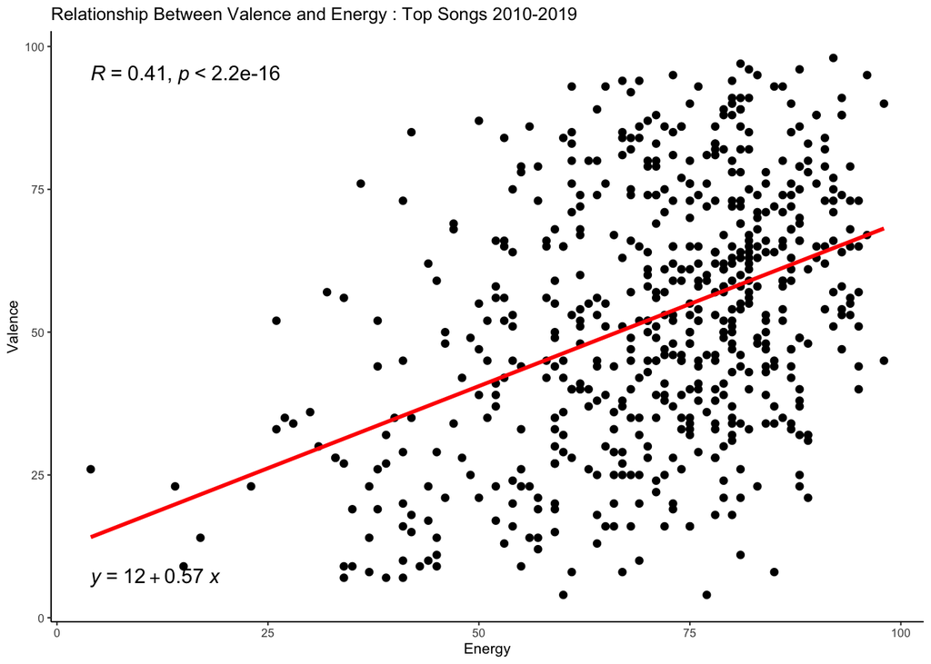

```r
spotify_data %>%
ggplot(aes(x = nrgy, y = val)) +
    geom_point() +
    stat_smooth(method = "lm",
        col = "red",
        se = FALSE,
        size = 1) +
  theme_classic(base_size = 8) +
  stat_cor() + # the retruns the correlation coefficient
  stat_regline_equation(label.y = 7)+ # this returns the GLM equation
  labs(title = "Relationship Between Valence and Energy : Top Songs 2010-2019",
       x = "Energy",
       y = "Valence")
```

## BUILDING A CLASSIFIER

Building a classifier to identify the genre of a song could improve Spotify’s classification. In looking through this data set, I have noticed that the genre of a song seems inextricably tied to the artist: it is a key assumption of this dataset that an artists songs are all within the same genre.

To try and improve the classification of music, I have built and trained a classifier to predict a song’s genre based on the characteristics of the music. Beyond improving genre’s accuracy, this could assist in playlist creation, and in identifying increasing interest in niche genres.

### Installing & Loading packages for building classifiers

I’ve installed and downloaded the caret package, and set the seed to a random number to make this machine learning experiment reproducible. I have also trimmed down the data to be only the variables relevant to the training set.

```r
library(caret)
trSpotify <-
  spotify_data%>%
  select(genre,bpm,nrgy,dnce,dB,live,val,dur,acous,spch,pop)

trSpotify$genre <- as.factor(trSpotify$genre)
glimpse(trSpotify)
```

```
## Rows: 588
## Columns: 11
## $ genre <fct> neo mellow, detroit hip hop, dance pop, dance pop, pop, canadian…
## $ bpm   <dbl> 97, 87, 120, 119, 109, 65, 120, 148, 93, 126, 128, 145, 130, 122…
## $ nrgy  <dbl> 89, 93, 84, 92, 84, 86, 78, 76, 37, 72, 87, 83, 82, 83, 84, 75, …
## $ dnce  <dbl> 67, 75, 76, 70, 64, 73, 75, 52, 48, 79, 62, 62, 77, 83, 44, 78, …
## $ dB    <dbl> -4, -5, -3, -4, -5, -5, -4, -6, -8, -4, -4, -5, -5, -6, -8, -6, …
## $ live  <dbl> 8, 52, 29, 8, 9, 11, 4, 12, 12, 7, 6, 10, 70, 11, 12, 36, 11, 60…
## $ val   <dbl> 80, 64, 71, 71, 43, 54, 82, 38, 14, 61, 47, 48, 63, 71, 78, 33, …
## $ dur   <dbl> 217, 263, 200, 295, 221, 214, 203, 225, 216, 235, 235, 230, 213,…
## $ acous <dbl> 19, 24, 10, 0, 2, 4, 0, 7, 74, 13, 3, 33, 18, 1, 1, 20, 5, 7, 0,…
## $ spch  <dbl> 4, 23, 14, 4, 4, 14, 9, 4, 3, 4, 3, 4, 5, 4, 45, 3, 3, 7, 5, 10,…
## $ pop   <dbl> 83, 82, 80, 79, 78, 77, 77, 77, 76, 73, 73, 73, 73, 73, 72, 72, …
```

The output shows that the dataset has one factor variable and 10 double class variables ### Data Partitioning The model is built on the training data set, and its performance is evaluated on a test dataset : I amusing the holdout validation approach to evaluating model performance.

The first line of code below sets the random seed for reproducibility of results.

The second and third lines then load the caTools package that I use for data partitioning, while the fourth to sixth lines create the training and test sets from the trSpotify dataset.

The training dataset contails 70% of the data, while the test dataset contails the remaining 30% :

```r
#Set Random Seed
set.seed(15)

#Install and Download caTools
library(caTools)

#Splitting the data
spl = sample.split(trSpotify$genre, SplitRatio = 0.7)
train = subset(trSpotify,spl == TRUE)
test = subset(trSpotify,spl == FALSE)

print(dim(train));print(dim(test))
```

```
## [1] 409  11
```

```
## [1] 179  11
```

### Building, Predicting and Evaluating the Model

To fit the logistic regression model, the first step is to instatiate the algoritm. I have done this using the glm() function. I have also printed the summary of the trained model :

```r
genre_glm = glm(genre~., family ="binomial", data=train)
summary(genre_glm)
```

```
##
## Call:
## glm(formula = genre ~ ., family = "binomial", data = train)
##
## Deviance Residuals:
##        Min          1Q      Median          3Q         Max
## -1.672e-04   2.100e-08   2.100e-08   2.100e-08   1.135e-04
##
## Coefficients:
##               Estimate Std. Error z value Pr(>|z|)
## (Intercept)  2.526e+02  6.881e+05   0.000    1.000
## bpm         -7.116e-01  5.098e+02  -0.001    0.999
## nrgy        -1.460e+00  3.106e+03   0.000    1.000
## dnce         9.318e-01  1.574e+03   0.001    1.000
## dB           2.587e+00  1.201e+04   0.000    1.000
## live         1.282e+00  1.041e+04   0.000    1.000
## val         -1.036e+00  1.121e+03  -0.001    0.999
## dur          3.663e-02  5.316e+02   0.000    1.000
## acous       -2.462e+00  2.052e+03  -0.001    0.999
## spch         9.151e-01  1.658e+03   0.001    1.000
## pop          1.826e+00  1.381e+03   0.001    0.999
##
## (Dispersion parameter for binomial family taken to be 1)
##
##     Null deviance: 1.4025e+01  on 408  degrees of freedom
## Residual deviance: 8.0367e-08  on 398  degrees of freedom
## AIC: 22
##
## Number of Fisher Scoring iterations: 25
```

Let’s evaluate the model further, starting by setting the baseline accuracy using the code below. Since the majority class of the target variable has a proportion of 325/588 = 0.55, the baseline accuracy is 55 percent.

```r
#Baseline Accuracy
prop.table(table(train$genre))
```

```
##
##              acoustic pop              alaska indie           alternative r&b
##               0.002444988               0.002444988               0.002444988
##                   art pop               atl hip hop          australian dance
##               0.014669927               0.007334963               0.009779951
##        australian hip hop            australian pop             barbadian pop
##               0.002444988               0.009779951               0.024449878
##               baroque pop               belgian edm                  big room
##               0.002444988               0.002444988               0.017114914
##                  boy band              british soul                   brostep
##               0.024449878               0.014669927               0.002444988
## canadian contemporary r&b          canadian hip hop            canadian latin
##               0.012224939               0.002444988               0.002444988
##              canadian pop                 candy pop               celtic rock
##               0.053789731               0.002444988               0.002444988
##               chicago rap             colombian pop                complextro
##               0.002444988               0.004889976               0.009779951
##      contemporary country                 dance pop                danish pop
##               0.002444988               0.555012225               0.002444988
##           detroit hip hop                 downtempo                       edm
##               0.002444988               0.002444988               0.007334963
##                   electro             electro house           electronic trap
##               0.002444988               0.002444988               0.002444988
##                electropop               escape room                  folk-pop
##               0.022004890               0.002444988               0.002444988
##          french indie pop                   hip hop                   hip pop
##               0.002444988               0.007334963               0.009779951
##                 hollywood                     house                 indie pop
##               0.002444988               0.002444988               0.002444988
##   irish singer-songwriter                     latin              metropopolis
##               0.002444988               0.007334963               0.002444988
##              moroccan pop                neo mellow            permanent wave
##               0.002444988               0.014669927               0.007334963
##                       pop            tropical house
##               0.095354523               0.002444988
```

I can now evaluate the model performance on the training and test data, which should ideally be better than the baseline accuracy. I can start by generating predictions on the training data, using the first line of code below. The second line cerates the confusion matrix with a threshhold of 0.5, which sets 0.5 likelihood as an indicator of a true positive.

The third line prints the accuracy of the model on the training data, using the confusion matrix.

```r
# Predictions on the training set
predictTrain = predict(genre_glm, data = train, type = "response")

# Confusion matrix on training data
table(train$genre, predictTrain >= 0.5)
```

```
##
##                             FALSE TRUE
##   acoustic pop                  1    0
##   alaska indie                  0    1
##   alternative r&b               0    1
##   art pop                       0    6
##   atl hip hop                   0    3
##   australian dance              0    4
##   australian hip hop            0    1
##   australian pop                0    4
##   barbadian pop                 0   10
##   baroque pop                   0    1
##   belgian edm                   0    1
##   big room                      0    7
##   boy band                      0   10
##   british soul                  0    6
##   brostep                       0    1
##   canadian contemporary r&b     0    5
##   canadian hip hop              0    1
##   canadian latin                0    1
##   canadian pop                  0   22
##   candy pop                     0    1
##   celtic rock                   0    1
##   chicago rap                   0    1
##   colombian pop                 0    2
##   complextro                    0    4
##   contemporary country          0    1
##   dance pop                     0  227
##   danish pop                    0    1
##   detroit hip hop               0    1
##   downtempo                     0    1
##   edm                           0    3
##   electro                       0    1
##   electro house                 0    1
##   electronic trap               0    1
##   electropop                    0    9
##   escape room                   0    1
##   folk-pop                      0    1
##   french indie pop              0    1
##   hip hop                       0    3
##   hip pop                       0    4
##   hollywood                     0    1
##   house                         0    1
##   indie pop                     0    1
##   irish singer-songwriter       0    1
##   latin                         0    3
##   metropopolis                  0    1
##   moroccan pop                  0    1
##   neo mellow                    0    6
##   permanent wave                0    3
##   pop                           0   39
##   tropical house                0    1
```

```r
409/nrow(train) #accuracy of training set
```

```
## [1] 1
```

```r
#Predictions on the test set
predictTest = predict(genre_glm, newdata = test, type = "response")

# Confusion matrix on test set
table(test$genre, predictTest >= 0.5)
```

```
##
##                             TRUE
##   acoustic pop                 1
##   alaska indie                 0
##   alternative r&b              0
##   art pop                      2
##   atl hip hop                  1
##   australian dance             2
##   australian hip hop           0
##   australian pop               1
##   barbadian pop                5
##   baroque pop                  1
##   belgian edm                  1
##   big room                     3
##   boy band                     5
##   british soul                 3
##   brostep                      1
##   canadian contemporary r&b    2
##   canadian hip hop             1
##   canadian latin               0
##   canadian pop                10
##   candy pop                    1
##   celtic rock                  0
##   chicago rap                  0
##   colombian pop                1
##   complextro                   2
##   contemporary country         0
##   dance pop                   98
##   danish pop                   0
##   detroit hip hop              1
##   downtempo                    1
##   edm                          1
##   electro                      1
##   electro house                0
##   electronic trap              1
##   electropop                   4
##   escape room                  1
##   folk-pop                     1
##   french indie pop             0
##   hip hop                      1
##   hip pop                      2
##   hollywood                    0
##   house                        0
##   indie pop                    1
##   irish singer-songwriter      0
##   latin                        1
##   metropopolis                 0
##   moroccan pop                 0
##   neo mellow                   3
##   permanent wave               1
##   pop                         17
##   tropical house               1
```

```r
178/nrow(test) #accuracy of testing set
```

```
## [1] 0.9944134
```